## Ch5

## Exercise 1

### 분산의 기본 통계적 성질을 사용하여 (5.6)을 유도하여라.

### 즉) (5.6)의 α는 Var(αX+(1-α)Y)를 최소화한다는 것을 증명하여라

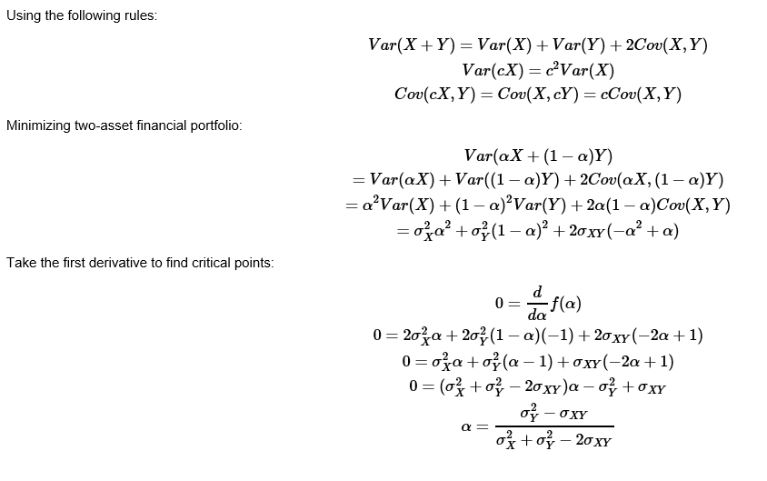

## Exercise 5

### (a) default를 예측하기 위해 income과 balance를 사용하는 로지스틱 회귀모델을 적합하여라

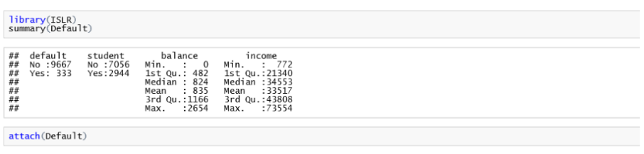

### balance : 월별 결제 후 고객이 신용 카드에 남아있는 평균 잔액

### income : 고객의 수익

### (b) 검증셋 기법을 사용하여 이 모델의 검정 오차를 추정하여라 검정오차를 추정하는 데는 다음 단계를 수행하여야 한다.

#### i. 표본셋을 훈련셋과 검증셋으로 분할한다.

#### ii. 훈련 관측치들만 사용하여 다중로지스틱 회귀모델을 적합한다.

#### iii. 검증셋 내 각 개인에 대한 연체 상태를 예측한다. 개인의 연체 상태는 그 사람에 대한 연체의 사후 확률을 계산하여 사후 확률이 0.5보다 크면 default(연체) 범주로 분류하여 얻는다.

#### iv. 검증셋 내의 관측치 중에서 잘못 분류된 관측치의 비율인 검증셋 오차를 계산한다.

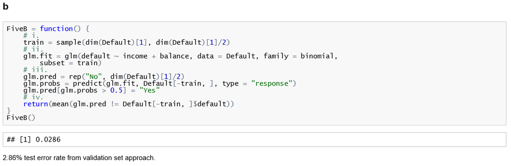

### (c) 관측치를 훈련셋과 검증셋으로 3번 다르게 분할하여 (b)의 과정을 3번 반복하고, 얻은 결과에 대해 설명하여라

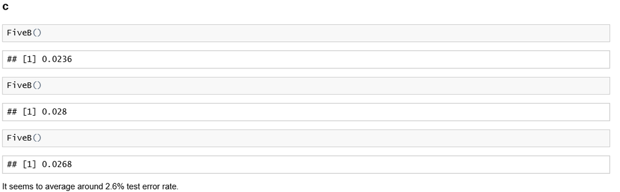

### (d) 이번에는 income, balance, 그리고 student에 대한 가변수를 사용하여 default 확률을 예측하는 로지스틱 회귀모델을 고려하고 검증셋 기법을 사용하여 이 모델에 대한 검정오차를 추정하여라. 그리고 student에 대한 가변수를 포함하는 것이 검정오차율을 줄이는지 설명하여라

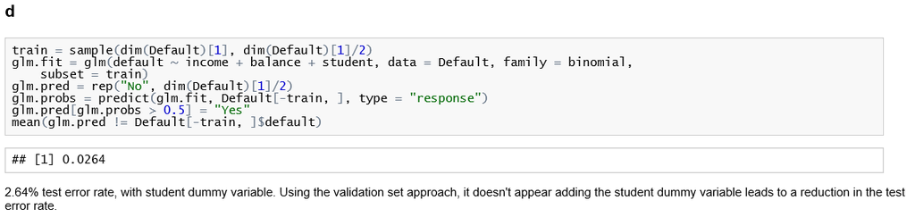